# s670-HW6

Ruchik Rohit Dama

12/2/2021

#### DISCUSSED WITH SUMANTH, ANIKET AND SHASHANK.

```r
min_data <- read.table("minnesota.barley.yield.txt",sep =" ", header = TRUE, dec =".")
```

```r
colnames(min_data)
```

```
## [1] "yield" "gen"   "year"  "site"
```

```r
min_data$year=as.factor(min_data$year)
min_data$site=as.factor(min_data$site)
min_data$yield=as.numeric(min_data$yield)
```

#### QUESTION 1:- Draw an appropriate faceted graph showing how barley yield varied by year at each location, using color as necessary. (Note: Lines might be better than dots here.) When looking at successive years, was it more common for the yields to move in the same direction at all locations, or was it more common for the yields to increase at some locations and decrease at others?

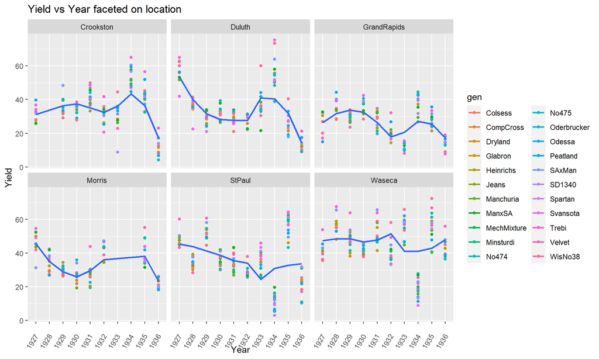

```r
ggplot( aes(x = year, y = yield,group=site,color=gen),data=min_data)+geom_point()+facet_wrap(~site)+ggtitle('Yield vs Year faceted on location')+geom_smooth(method=loess,se=FALSE)+xlab('Year')+ylab('Yield')+theme(axis.text.x = element_text(angle = 60, vjust = 0.5, hjust=1))
```

#### QUESTION 2:-Fit a model with yield as the response and gen (variety), year, and site as explanatory variables, with the goal of determining whether Morris 1931-1932 is an anomaly. Justify why you chose this model and not some other one.

```r
min_data$years = as.factor(min_data$year)
min_data$sites = as.factor(min_data$site)
min_data.lm=lm(yield~gen+years+sites+years:sites,data=min_data)
```

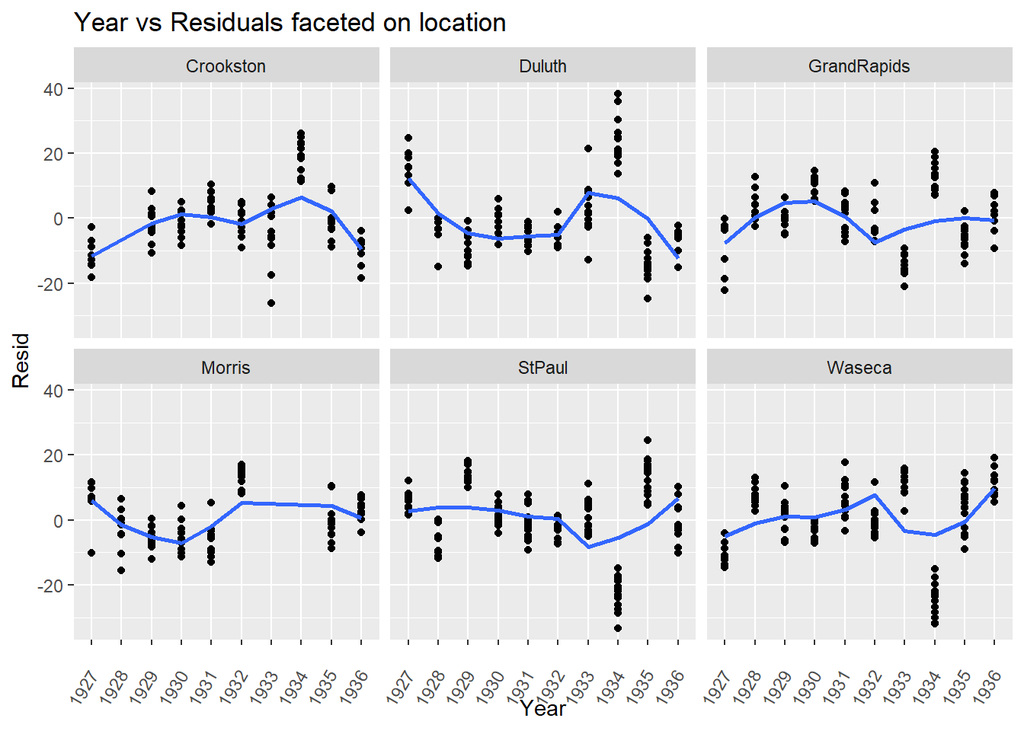

```r
mdata=min_data
mdata.lm=lm(yield~gen+years+site,data=mdata)
mdata$resid=residuals(mdata.lm)
ggplot(mdata,aes(x=year,y=resid,group=site))+geom_point()+facet_wrap(~site)+geom_smooth(method= loess,se=FALSE)+xlab('Year')+ylab('Resid')+ggtitle('Year vs Residuals faceted on location')+theme(axis.text.x = element_text(angle = 60, vjust = 0.5, hjust=1))
```

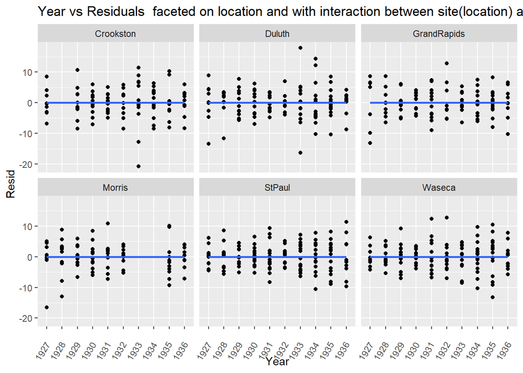

```r
library(broom)
mdata=min_data
mdata.lm=lm(yield~gen+years+site+years*site,data=mdata)
mdata$resid=residuals(mdata.lm)
ggplot(mdata,aes(x=year,y=resid,group=site))+geom_point()+facet_wrap(~site)+geom_smooth(method= loess,se=FALSE)+xlab('Year')+ylab('Resid')+ggtitle('Year vs Residuals  faceted on location and with interaction between site(location) and years') +theme(axis.text.x = element_text(angle = 60, vjust = 0.5, hjust=1))
```

```r
barley.effects=dummy.coef(min_data.lm) #gen+years+site+years:site
barley.effects
```

[output not shown]

[output cut: 72 more lines]

[output not shown]

```r
year.site.main=outer(barley.effects$years,barley.effects$sites,'+')
year.site.main
```

```
##       Crookston     Duluth GrandRapids     Morris    StPaul     Waseca
## 1927  0.0000000  3.8829341  -3.5930664  5.5842063  2.940121  4.9074664
## 1928 -6.0225260 -2.1395919  -9.6155924 -0.4383197 -3.082405 -1.1150596
## 1929  2.2509755  6.1339095  -1.3420909  7.8351818  5.191096  7.1584419
## 1930 -0.3477006  3.5352334  -3.9407671  5.2365057  2.592420  4.5597658
## 1931 -4.7648395 -0.8819055  -8.3579059  0.8193668 -1.824719  0.1426269
## 1932  0.8245206  4.7074547  -2.7685458  6.4087269  3.764642  5.7319870
## 1933  4.3215811  8.2045151   0.7285147  9.9057874  7.261702  9.2290475
## 1934  2.5877144  6.4706485  -1.0053520  8.1719207  5.527835  7.4951808
## 1935  5.1634015  9.0463356   1.5703351 10.7476078  8.103522 10.0708680
## 1936  2.3494494  6.2323835  -1.2436170  7.9336557  5.289570  7.2569159
```

```r
year.site.inter=barley.effects$"years:sites"
year.site.inter
```

```
##   1927:Crookston   1928:Crookston   1929:Crookston   1930:Crookston
##        0.0000000        0.0000000        0.0000000        0.0000000
##   1931:Crookston   1932:Crookston   1933:Crookston   1934:Crookston
##        0.0000000        0.0000000        0.0000000        0.0000000
##   1935:Crookston   1936:Crookston      1927:Duluth      1928:Duluth
##        0.0000000        0.0000000        0.0000000        2.6620732
##      1929:Duluth      1930:Duluth      1931:Duluth      1932:Duluth
##        3.5062431        1.7140604        8.6050332        2.0594192
##      1933:Duluth      1934:Duluth      1935:Duluth      1936:Duluth
##        8.6636508       16.6169535        4.5268172        2.5631808
## 1927:GrandRapids 1928:GrandRapids 1929:GrandRapids 1930:GrandRapids
##        0.0000000       10.2158778       -1.0899414       -1.4675995
## 1931:GrandRapids 1932:GrandRapids 1933:GrandRapids 1934:GrandRapids
##       21.7990672       10.3657338      -19.9304173       25.1888889
## 1935:GrandRapids 1936:GrandRapids      1927:Morris      1928:Morris
##       -6.6136265       14.5222222        0.0000000       17.0161387
##      1929:Morris      1930:Morris      1931:Morris      1932:Morris
##       10.4555556      -37.7391757      -33.4979798      -26.9616162
##      1933:Morris      1934:Morris      1935:Morris      1936:Morris
##      -37.9883315      -30.9949087      -18.5265545      -22.7811536
##      1927:StPaul      1928:StPaul      1929:StPaul      1930:StPaul
##        0.0000000      -40.6093587      -23.2444444       -5.6255492
##      1931:StPaul      1932:StPaul      1933:StPaul      1934:StPaul
##        0.0772629        8.3499902       -7.2402196       -3.3963735
##      1935:StPaul      1936:StPaul      1927:Waseca      1928:Waseca
##      -11.9972110       -8.9863735        0.0000000       -7.8030401
##      1929:Waseca      1930:Waseca      1931:Waseca      1932:Waseca
##        8.7580710      -27.7255545      -21.1222222      -21.8676768
##      1933:Waseca      1934:Waseca      1935:Waseca      1936:Waseca
##      -28.7529915       -3.7432853        0.0000000        0.0000000
```

```r
year.site.effect=year.site.main+year.site.inter
year.site.effect
```

```
##       Crookston     Duluth GrandRapids     Morris      StPaul     Waseca
## 1927  0.0000000  3.8829341  -3.5930664   5.584206   2.9401210   4.907466
## 1928 -6.0225260  0.5224813   0.6002854  16.577819 -43.6917638  -8.918100
## 1929  2.2509755  9.6401526  -2.4320323  18.290737 -18.0533480  15.916513
## 1930 -0.3477006  5.2492938  -5.4083665 -32.502670  -3.0331289 -23.165789
## 1931 -4.7648395  7.7231278  13.4411613 -32.678613  -1.7474557 -20.979595
## 1932  0.8245206  6.7668739   7.5971880 -20.552889  12.1146317 -16.135690
## 1933  4.3215811 16.8681659 -19.2019027 -28.082544   0.0214824 -19.523944
## 1934  2.5877144 23.0876019  24.1835369 -22.822988   2.1314619   3.751896
## 1935  5.1634015 13.5731528  -5.0432914  -7.778947  -3.8936885  10.070868
## 1936  2.3494494  8.7955643  13.2786052 -14.847498  -3.6968031   7.256916
```

```r
years=rep(rownames(year.site.main),6)
sites=rep(colnames(year.site.main),each=10)
year.site.df=data.frame(year=years,site=sites,effect=as.vector(year.site.effect ))
#View(year.site.df)
```

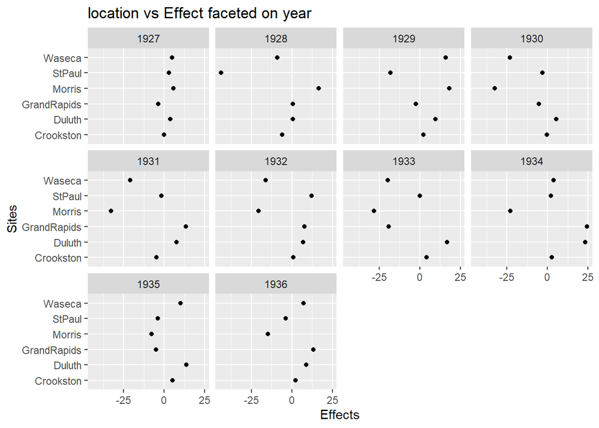

```r
ggplot(year.site.df,aes(x=effect,y=site))+geom_point()+facet_wrap(~year)+xlab('Effects')+ylab('Sites')+ggtitle('location vs Effect faceted on year')
```

#### QuESTION 3:- Draw plots of the fit and/or residuals with the goal of determining whether Morris 1931-1932 is a mistake, or whether it can be explained as natural variation. As best as you can tell, was there a mistake?

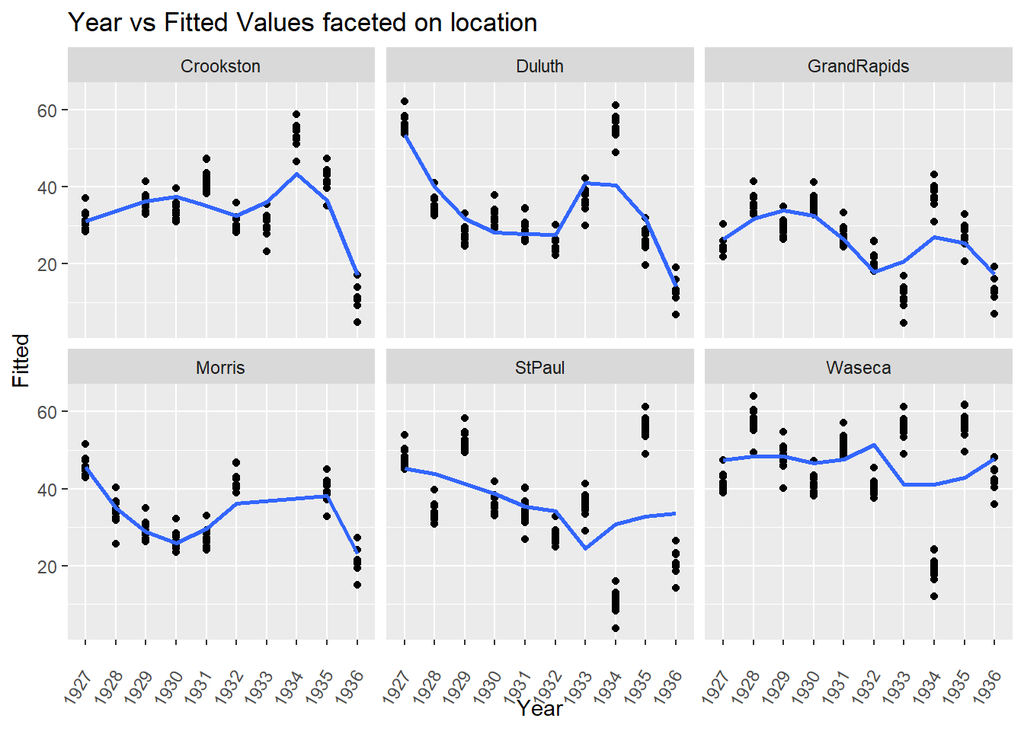

```r
mdata=min_data
mdata.lm=lm(yield~gen+years+site+years:site,data=mdata)

mdata$preds=fitted.values(mdata.lm)
mdata$resid=residuals(mdata.lm)
ggplot(mdata,aes(x=year,y=preds,group=site))+geom_point()+facet_wrap(~site)+geom_smooth(method= loess,se=FALSE)+xlab('Year')+ylab('Fitted')+ggtitle('Year vs Fitted Values faceted on location') +theme(axis.text.x = element_text(angle = 60, vjust = 0.5, hjust=1))
```

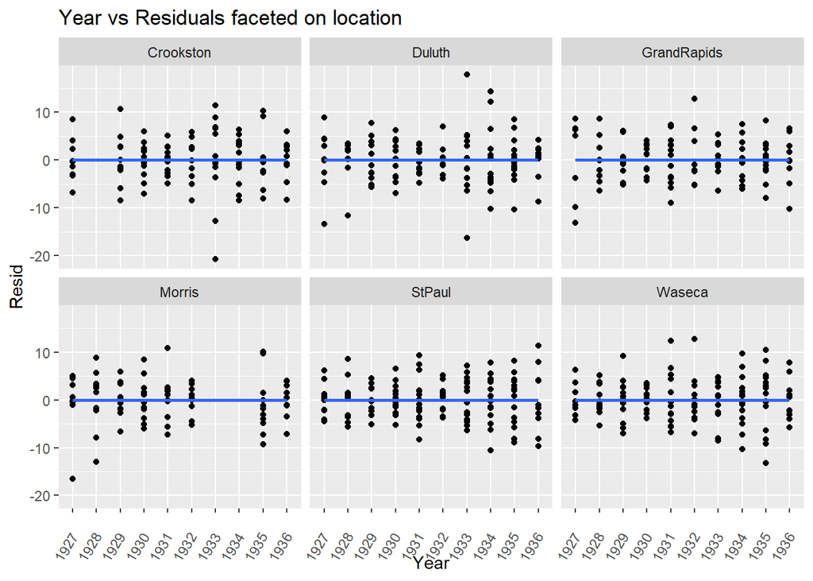

```r
ggplot(mdata,aes(x=year,y=resid,group=site))+geom_point()+facet_wrap(~site)+geom_smooth(method= loess,se=FALSE)+xlab('Year')+ylab('Resid')+ggtitle('Year vs Residuals faceted on location') +theme(axis.text.x = element_text(angle = 60, vjust = 0.5, hjust=1))
```

#### By looking at the residuals we can see that there is no particular pattern being followed and they seem to be randomly scatters around the zero line, by which we can say that it is a good model to judge. As we can see from the fitted and residuals model plotted above as well, the 1931-1932 data of Morris may not be a mistake. As you can see from the fitted graph, the yield increased between 1930 and 1935, and the fitted values of 1932 follow this trend as well, which indicates that the adjusted values are not wrong.